# 170106_BetaDiversityDistancesOrdination

Thorsten Brach

6/1/2017

# Packages

```r
try(library(dada2), biocLite("dada2"))
```

```r
## Short Read
try(library(phyloseq), biocLite("phyloseq"))

## ggplot2
try(library(ggplot2), install.packages("ggplot2"))

## dplyr
try(library(dplyr), install.packages("dplyr"))
## tidyr
try(library(tidyr), install.packages("tidyr"))

## gridExtra
try(library(gridExtra), install.packages("gridExtra"))
```

# Background

We want to measure and illustrate how similar/distant the microbial communities are in different samples (= beta-diversity). Alpha-diversity (often just richness, or richness plus evenness) measures tell us how diverse a individual sample is, now we want to know how similar/distant different samples are to each other. Are the samples from patients more similar to each other than to healthy controls?

The first step is therefore to calculate distances between the samples (the beta-diversity) (see http://cnx.org/contents/t8i_eHU4@2/Alpha-Beta-and-Gamma-Diversity). The second step is then to illustrate the distances in a two or three dimensional coordinate frame.

# Calculating distances between microbial communities (beta-diversity measures)

## Preprocessing the Global Patterns example data

- this sample data contains human samples from Feces, Mock, Skin, and Tongue, and you would expect that samples from the same “area” should be more similar to each other
- NB: we change to relative abundances here on the way, because some distance measures seem to only work on relative abundances (??)

```r
## example physeq
data(GlobalPatterns)
GP <- GlobalPatterns
# ntaxa(GP) # 19216

## Filtering the GP to reduce processing time
# keep only human samples
sample_data(GP)$human = factor( get_variable(GP, "SampleType") %in% c("Feces", "Mock", "Skin", "Tongue") )

GPh <- subset_samples(GP, subset = human == TRUE )

## keep only taxa present in at least 30% of samples
GPhf <- filter_taxa(GPh, function(x){sum(x != 0) > .3*length(x)}, prune = TRUE) # still 3670 taxa

## do their normalisation
total = median(sample_sums(GPhf))
standf = function(x, t=total) round(t * (x / sum(x)))
GPhfs = transform_sample_counts(GPhf, standf)
#range(sample_sums(GPhfs))

## change to relative abundance here
GPhfs = transform_sample_counts(GPhfs, function(x){x/sum(x)})

## keep only taxa with good variation
GPhfsf = filter_taxa(GPhfs, function(x) sd(x)/mean(x) > 3.0, prune = TRUE) # down to 388 taxa
sample_sums(GPhfsf) # again very different but I think fine since all have now same taxa
```

```
##      M31Fcsw      M11Fcsw      M31Plmr      M11Plmr      F21Plmr
## 0.1031964703 0.3429945167 0.0848682962 0.4562268937 0.1307620302
##      M31Tong      M11Tong         TS28         TS29        Even1
## 0.2727306505 0.2582580879 0.1174905810 0.0613781752 0.0012996958
##        Even2        Even3
## 0.0009098896 0.0014464802
```

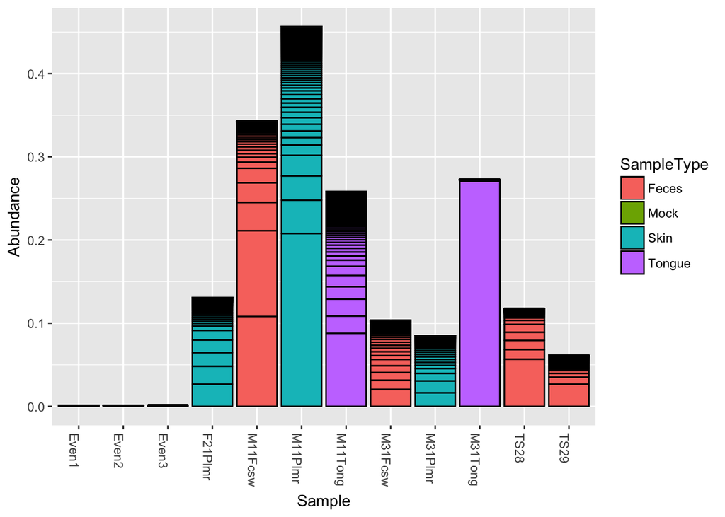

```r
plot_bar(GPhfsf, x = "Sample", y = "Abundance", fill = "SampleType")
```

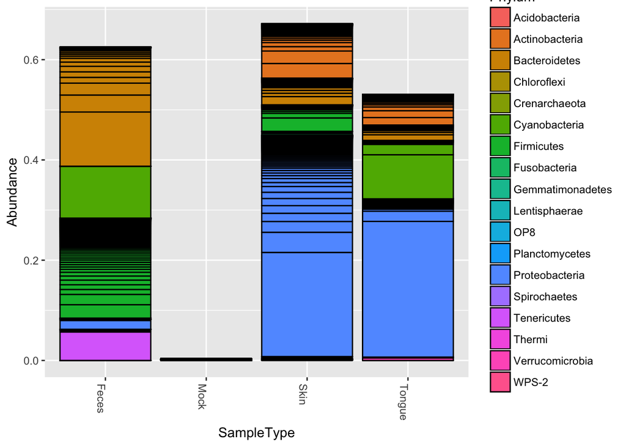

```r
plot_bar(GPhfsf, x = "SampleType", y = "Abundance", fill = "Phylum")
```

## Calculate different distances and understand at least some

```r
# phyloseq offers a lot of distance methods
dist_methods <- unlist(distanceMethodList)
# I reduce
dist_methods <- dist_methods[dist_methods %in% c("unifrac", "wunifrac", "jsd", "canberra", "bray", "jaccard", "euclidean")]

dist_methods
```

```
##    UniFrac1    UniFrac2         JSD    vegdist2    vegdist3    vegdist4
##   "unifrac"  "wunifrac"       "jsd" "euclidean"  "canberra"      "bray"
##    vegdist6
##   "jaccard"
```

### Calculate the distance matrixes with phyloseq and try to recapitulate some of them

- NB: UniFrac requires a phylogenetic tree that is present in this sample data

```r
# NB: UniFrac requires a tree! GP has a tree

Distlist <- vector("list", length(dist_methods))
names(Distlist) = dist_methods

for( i in dist_methods ){
        # Calculate distance matrix
        iDist <- phyloseq::distance(GPhfsf, method=i)
        Distlist[[i]] = iDist
}
```

#### recapitulate Euclidean distance

```r
# phyloseq makes use here of the vegan package
DistEucl <- vegan::vegdist(t(as(otu_table(GPhfsf), "matrix")), method = 'euclidean')

identical(as(DistEucl, "matrix"), as(Distlist$euclidean, "matrix"))
```

```
## [1] TRUE
```

```r
# the function (type vegan::vegdist) is unfortunately based on C code
# but ?vegan::vegdist shows you
# euclidean d[jk] = sqrt(sum(x[ij]-x[ik])^2) # but actually it is sqrt(sum((x[ij]-x[ik])^2))
# THINK of a2 + b2 = c2, then c <- sqrt(a2 + b2)
# j and k refer to the two samples to be compared
# i to the current taxa

##### Own Euclidean distance
# First example for only a few samples
physeq <- GPhfsf
if(taxa_are_rows(physeq)){
        DF <- as.data.frame(otu_table(physeq))
} else {
        DF <- as.data.frame(t(otu_table(physeq)))
}

colnames(DF)[1:2] # "M31Fcsw" "M11Fcsw"
```

```
## [1] "M31Fcsw" "M11Fcsw"
```

```r
Dist12 <- sqrt(sum((DF[,1]-DF[,2])^2))
all.equal(Dist12, DistEucl[1]) # TRUE!
```

```
## [1] TRUE
```

```r
# how to implement this, basically column wise calculation
physeq <- GPhfsf
if(taxa_are_rows(physeq)){
        DF <- as(otu_table(physeq), "matrix")
} else {
        DF <- as(t(otu_table(physeq)), "matrix")
}

## Long way (computationally) with apply and sapply:
EuclDistMatrix <- sapply(1:ncol(DF), function(y){apply(DF, 2, function(x){sqrt(sum((x-DF[,y])^2))})})
colnames(EuclDistMatrix) <- rownames(EuclDistMatrix)
# compare:
DistEuclM <- as(DistEucl, "matrix")
all.equal(DistEuclM, EuclDistMatrix) # TRUE
```

```
## [1] TRUE
```

- NB: I like the apply way here, but it is of course not computationally super efficient, Check:
- http://stackoverflow.com/questions/34757217/fastest-way-to-apply-function-to-all-pairwise-combinations-of-columns
- thus the data.table package might be smart to learn (in c), I could not figure it out easily here, at for small sample sizes I guess the apply solution is good enough

```r
# library(data.table)
# data.DT <- setkey(data.table(c(DF), colId = rep(1:ncol(DF), each = nrow(DF)), rowId = rep(1:nrow(DF), times = ncol(DF))), colId)
#
# diff.DT <- data.DT[
#   , {
#     ccl <- unique(colId)
#     vv <- V1
#     data.DT[colId > ccl, .(col2 = colId, V1 - vv)]
#   }
#   , keyby = .(col1 = colId)
# ]
```

#### recapitulate Bray Curtis distance

```r
# phyloseq makes also here use of the vegan package
DistBray <- vegan::vegdist(t(as(otu_table(GPhfsf), "matrix")), method = 'bray')

identical(as(DistBray, "matrix"), as(Distlist$bray, "matrix"))
```

```
## [1] TRUE
```

```r
##### Own Bray distance distance
# from ?vegan::vegdist
# bray  d[jk] = (sum abs(x[ij]-x[ik]))/(sum (x[ij]+x[ik]))

physeq <- GPhfsf
if(taxa_are_rows(physeq)){
        DF <- as(otu_table(physeq), "matrix")
} else {
        DF <- as(t(otu_table(physeq)), "matrix")
}

## Long way (computationally) with apply and sapply:
BrayDistMatrix <- sapply(1:ncol(DF), function(y){apply(DF, 2, function(x){ sum(abs(x-DF[,y]))/sum(x + DF[,y]) })})
colnames(BrayDistMatrix) <- rownames(BrayDistMatrix)
# compare:
DistBrayM <- as(DistBray, "matrix")
all.equal(DistBrayM, BrayDistMatrix) # TRUE
```

```
## [1] TRUE
```

### Summary Distances

- you should really think about which distance could make most sense for your data and understand the ideas behind some of them
- as shown, implementation is easy
- so know you have distances between the different samples
  - **In a way these are all beta diversity measures?**
- How to use those distances to cluster the samples in 2 or 3 dimensions? >> Ordination

# Ordination: Using the distances to cluster the samples in two dimensions

## Background/Understanding

- beta diversity: is the difference between the microbial distribution of samples. In the simplest case it could just be the sum of species that are only found in one sample and not the other.
- ordination plots, especially PCoA (multidimensional scaling) is about the question: if I give you the distances between cities, can you draw a map?
  - and now imagine the distances come from more than two dimensions, can you then draw the best map in two dimensions

### Simple example of workflow

```r
# you have your distance matrices (Distlist)

## Example of how to get to the ordination plot with phyloseq
MDS  <- ordinate(GPhfsf, "MDS", distance=Distlist[["bray"]]) # NB "MDS" is equal to "PCoA", MDS is even of class "pcoa"
PCoA <- ordinate(GPhfsf, "PCoA", distance=Distlist[["bray"]])
identical(MDS, PCoA) # TRUE!!
```

```
## [1] TRUE
```

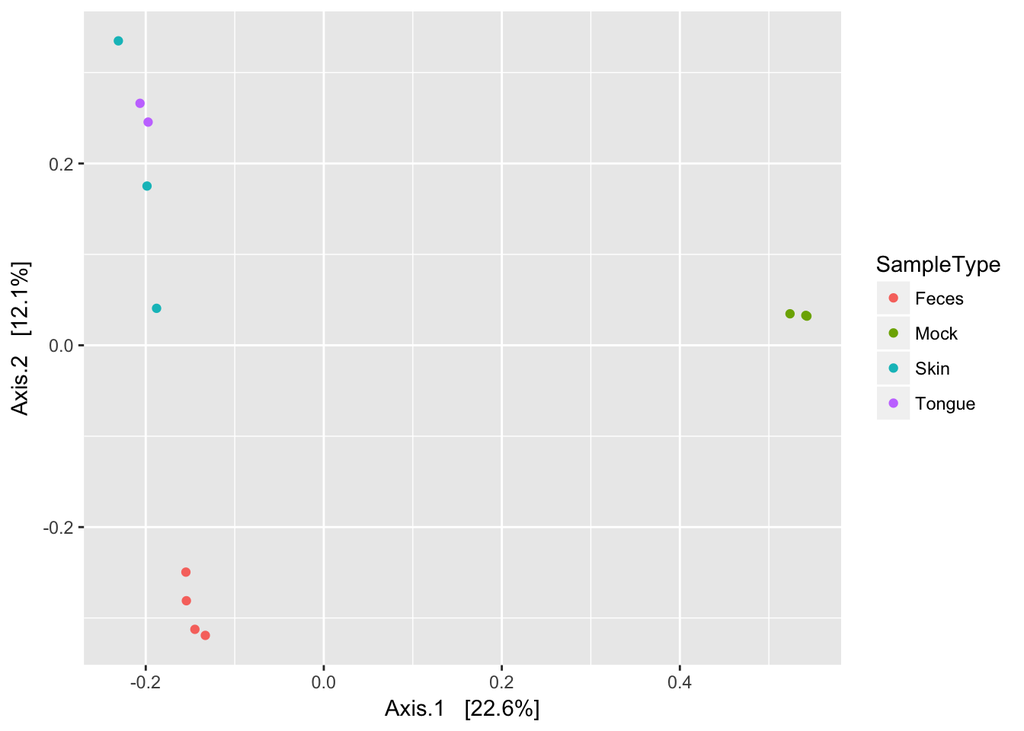

```r
p <- plot_ordination(GPhfsf, MDS, color="SampleType")
p
```

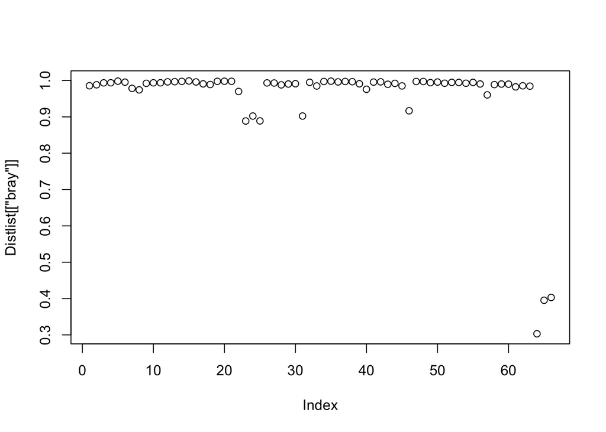

```r
# so here it looks like the three Mock samples are furthest away from the others
plot(Distlist[["bray"]])
```

```r
# only 3 distances are small, the ones called Even, and indeed these are the Mock samples
#sample_data(GPhfsf)
```

### Example with only 2 dimensions (taxa) to understand MDS/PCoA better

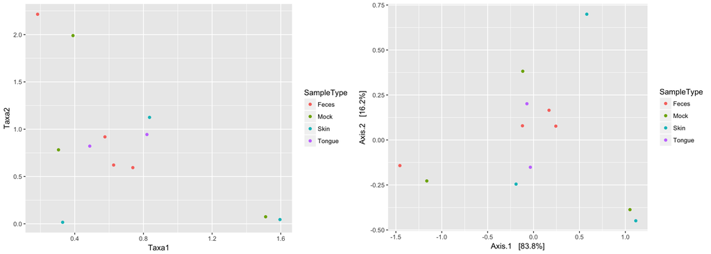

```r
############ Attempt to check if I have data with only 2 dimensions (2 taxa), then I calculate the Eucledian distance, and then I do MDS, do I get the map back?? #######################
set.seed(1)
x <- abs(rnorm(12))
y <- abs(rnorm(12))
df <- t(data.frame(Taxa1 = x, Taxa2 = y))
colnames(df) <- sample_names(GPhfsf)
# for plot comparisoin
dfplot <- as.data.frame(t(df))
dfplot$SampleType <- as.character(as.data.frame(sample_data(GPhfsf))$SampleType)
Testphy <- phyloseq(otu_table(as.matrix(df), taxa_are_rows = TRUE), sample_data(GPhfsf))
ED <- phyloseq::distance(Testphy, method="euclidean")
MDSTest <- ordinate(Testphy, "PCoA", distance=ED)
p <- plot_ordination(Testphy, MDSTest, color="SampleType")
comp <- ggplot(dfplot, aes(x = Taxa1, y = Taxa2, color = SampleType))
comp <- comp + geom_point()
grid.arrange(comp, p, nrow = 1)
```

- Similarity is clear, a bit turned and stretched, NB: 100% of variability in first 2 axes!
- NB: on the plot the distances seem not conserved on first sight, but that is because (seet(1)) the first axis explains more variability than the second?

#### NB: plot_ordination uses physeq object only for sample_data, i.e. the coloring, the rest is saved in the MDS

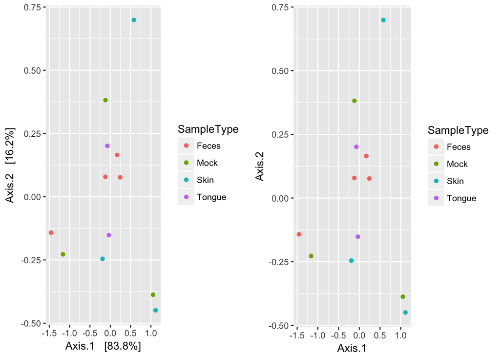

```r
dff <- as.data.frame(MDSTest[["vectors"]])
dff$SampleType <- as.character(as.data.frame(sample_data(GPhfsf))$SampleType)
tr <- ggplot(dff, aes(x = Axis.1, y = Axis.2, color = SampleType))
tr <- tr + geom_point()
grid.arrange(p, tr, nrow = 1)
```

```r
# and note for the percentages:
MDSTest$values$Relative_eig
```

```
## [1] 0.8379182 0.1620818
```

## Understanding the phyloseq::ordinate function

- NB: the Distance matrix only contains distance info for the different samples, it does not contain info about the dimension of the original data (number of taxa)
- Many of the offered methods, including “PCoA”, do not make use of the physeq object, they only needed the Distance matrix
- The ape::pcoa function is used for pcoa, question is how it from the distances determines how many axes to calculate (principal components?)

```r
# # Understanding phyloseq::ordinate
# #function (physeq, method = "PCoA", distance = "bray", formula = NULL,  ...)
#
# #NB: distance: can also be directly a dist-class object. IT IS ONLY USED IF THE ORDINATION METHOD REQUIRES A DIST MATRIX
#
# method_table <- c("DCA", "CCA", "RDA", "CAP", "DPCoA", "NMDS",
#                           "MDS", "PCoA")
#
# # If distance is not directly given  well then it is calculated with the distance function
# if (inherits(distance, "dist")) {
#         ps.dist <- distance
# } else if (class(distance) == "character") {
#         vegdist_methods <- c("manhattan", "euclidean", "canberra",
#                              "bray", "kulczynski", "jaccard", "gower", "altGower",
#                              "morisita", "horn", "mountford", "raup", "binomial",
#                              "chao")
#         if (method == "NMDS" & distance %in% vegdist_methods) {
#                 return(metaMDS(veganifyOTU(physeq), distance, ...))
#         }
#         ps.dist <- distance(physeq, distance)
# }
# # at the latest now you have ps.dist, the dist object
#
# # NB for pcoa then the function simply calls:
# pcoa(ps.dist) # but there is little information on it, it is however to assume that they simply use the ape package pcoa funciton
#
# ape::pcoa(ps.dist)
```

## Understanding the plot_ordination function

- type plot_ordination to get the function
- It is based on the vegan::scores function but I could not reproduce this

```r
# To reproduce
Obj <- plot_ordination(physeq = GPhfsf, ordination = MDS) # returns a ggplot object

# see
# ?vegan::scores()
```

# Reproducing “Euclidean” and PCoA with the base package

```r
# First again the phyloseq method
physeq <- GPhfsf
#1.) The Distance measure
EucDist <- phyloseq::distance(physeq, method="euclidean")
# 2.) The PCoA
EucOrd <- ordinate(physeq, "PCoA", distance=EucDist)
# 3.) Plotting the PCoA
EucPlot <- plot_ordination(physeq, ordination = EucOrd)

# Reproduce and understand with the underlying functions
# 1.) Distance measure
if(taxa_are_rows(physeq)){
        DF <- as(otu_table(physeq), "matrix")
} else {
        DF <- as(t(otu_table(physeq)), "matrix")
}

EuclDistMatrix <- sapply(1:ncol(DF), function(y){apply(DF, 2, function(x){sqrt(sum((x-DF[,y])^2))})})
colnames(EuclDistMatrix) <- rownames(EuclDistMatrix)
EucDistS <- EuclDistMatrix[lower.tri(EuclDistMatrix)]
# here I cheat a bit
attributes(EucDistS) <- attributes(EucDist)
all.equal(EucDistS, EucDist)
```

```
## [1] TRUE
```

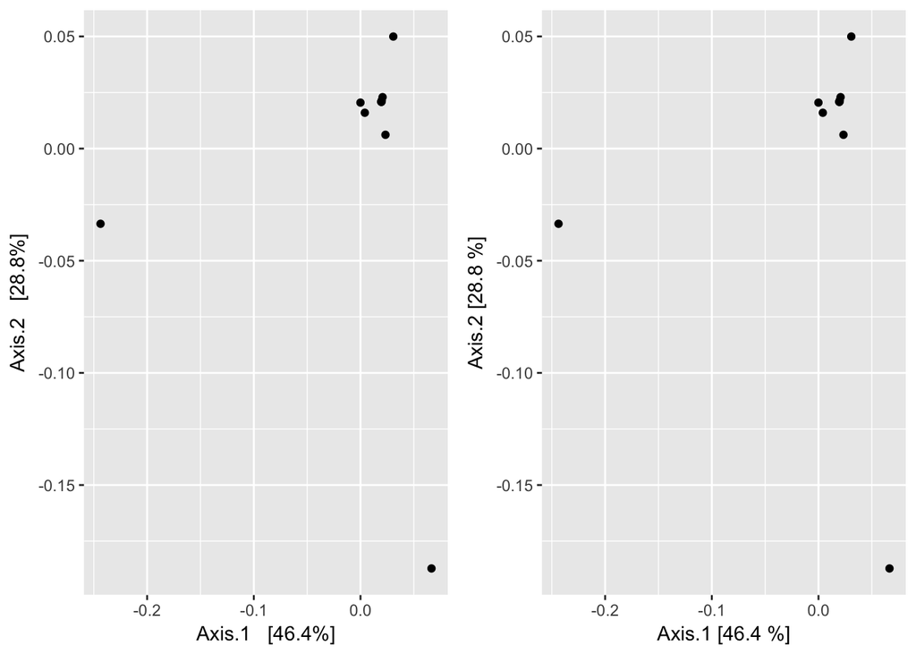

```r
# 2.) The PCoA
## for this you have to understand the ape::pcoa function (do that in the future) and understand the PCA in it.
EucOrdS <- ape::pcoa(EucDistS)

# 3.) The plot
dff <- as.data.frame(EucOrdS[["vectors"]])
EucPlotS <- ggplot(dff, aes(x = Axis.1, y = Axis.2))
EucPlotS <- EucPlotS + geom_point()
xL <- paste("Axis.1 [", round(EucOrdS$values$Relative_eig[1]*100,1), " %]", sep = "")
yL <- paste("Axis.2 [", round(EucOrdS$values$Relative_eig[2]*100,1), " %]", sep = "")
EucPlotS <- EucPlotS + xlab(xL) + ylab(yL)
grid.arrange(EucPlot, EucPlotS, nrow = 1)
```

```r
# NB also
EucOrd$values$Eigenvalues/sum(EucOrd$values$Eigenvalues)
```

```
## [1] 0.463574550 0.288401943 0.149041496 0.055018498 0.022279534 0.009994168
## [7] 0.005691337 0.004090180 0.001908295
```

```r
# the proportion of total variation as the Eigenvalue divided by the sum of the Eigenvalues
# Mathematically, PCA is just an eigen analysis: the covariance (or correlation) matrix is decomposed into its Eigenvectors and Eigenvalues. The Eigenvectors are the rotations to the new axes, and the Eigenvalues are the amount of stretching that needs to be done.



# svd1 <- svd(df)
# plot(svd1$v[, 1], xlab = "Column", ylab = "First right singular vector", pch = 19)
# plot(svd1$d^2/sum(svd1$d^2), xlab = "Column", ylab = "Proportion of variance explained",
#      pch = 19)
# pca1 <- prcomp(df, scale = FALSE)
```